# R2-05 – STATISTIQUE DESCRIPTIVE 2 - Statistique bivariée – Ajustement -

Devoir Maison

Ibrahim BENKHERFELLAH & Axel COULET

21/02/2025

# **Exercice n°1**

Même s’il y en a qu’un seul…

## **Question 1 :**

Tout d’abord, qu’est-ce qu’une variable explicative et une variable expliquée ?

- Une variable explicative est la variable qui permet d’expliquer une autre variable. Elle est souvent notée $X$. Sur une représentation graphique, la variable explicative est représentée en abscisse.
- Une variable expliquée est la variable pour laquelle on cherche un modèle de prévision. Son évolution dépend d’une ou de plusieurs autres variables. Elle est souvent notée $Y$. Sur une représentation graphique, la variable expliquée est représentée en ordonnée.

Ainsi, dans le cadre de notre exercice, la variable explicative est le **dosage de sérum X (en mL)**. Et la variable expliquée est la **quantité de bactéries Y (en UFC/mL)**, car c’est celle qui est mesurée en fonction du dosage de sérum et qui dépend potentiellement de $X$.

## **Question 2 :**

Représentation du nuage de points de la statistique bi-variée ($x_{i};y_{i}$) :

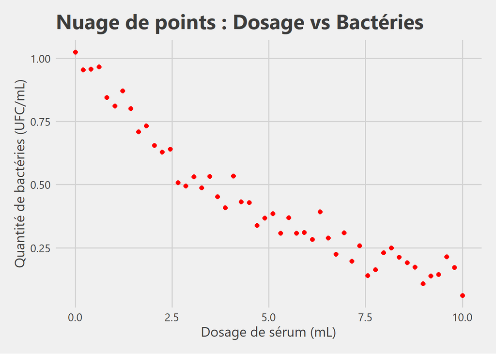

## **Question 3 :**

### a) Calcul de la moyenne et de la variance de la quantité de bactéries

**Résultats du code R**

```
## Moyenne de la quantité de bactéries :  0.4389205
```

```
## Variance de la quantité de bactéries :  0.06711594
```

- Moyenne : $\overline{y} = ~$ **0,4389205**
- Variance : $\sigma^2 = ~$ **0,0671159**

**Attention :** Ici, la variance est calculée selon la formule de Pearson. Il s’agit de la moyenne des carrés des écarts à la moyenne.

### b) Box-plot de la dsitribution de la variable : **Quantité de bactéries**

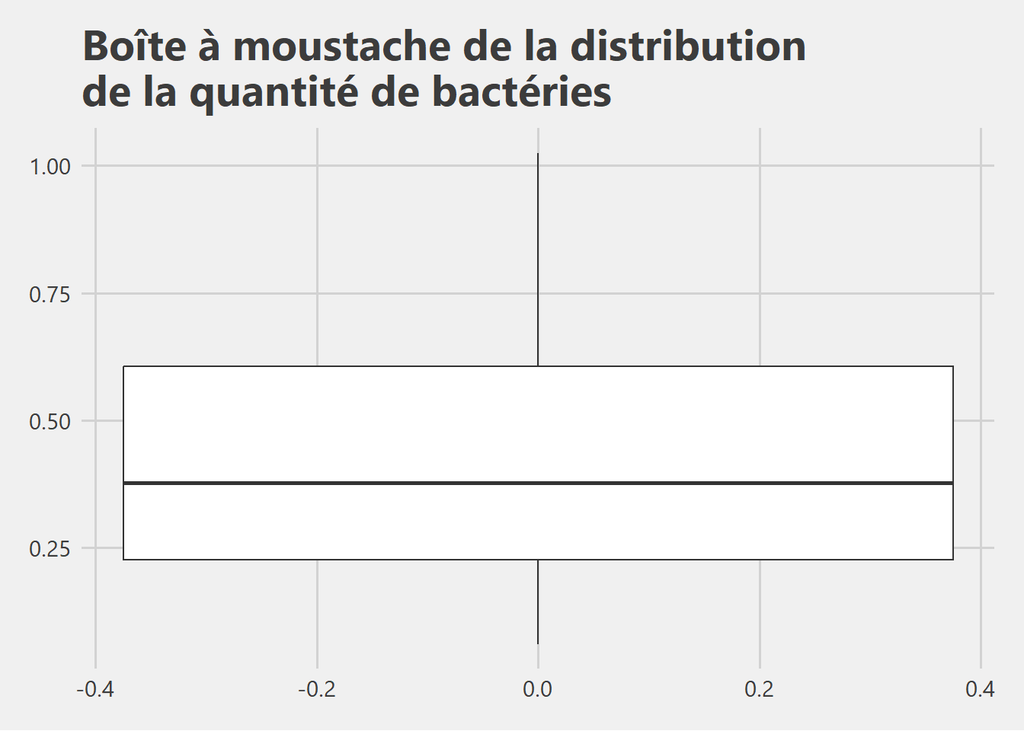

## **Question 4 :**

Nous savons que la Covariance de $x$ et $y$ est :

$$Cov(x,y) =
\frac{1}{n}\sum_{i=1}^{i=n}(x_i - \overline{x})(y_i - \overline{y}) =
(\frac{1}{n}\sum_{i=1}^{i=n}(x_iy_i)) -
\overline{x}\overline{y}$$

```
## Covariance entre X et Y :  -0.7243548
```

On trouve donc : **$Cov(x, y) = -0,7243548$**

La covariance entre les deux variables étant de **$-0,7243548$**, cela indique une assez forte relation. Le signe étant négative, cela indique que $X$ et $Y$ évoluent de manière opposé. Autrement dit, lorsque $X$ augmente, $Y$ quant à lui à diminuer, et inversement. Ce qui coincide avec l’observation faite ci-dessus, dans le nuage de point.

## **Question 5 :**

Les Q-Q plots (Quantile-Quantile plots) permettent de comparer les quantiles d’une variable observée à ceux d’une distribution théorique, souvent la distribution normale. En examinant l’alignement des points sur une droite diagonale, il est possible d’évaluer visuellement si une variable suit une distribution normale.

### a) Etude graphique Quantile-Quantile

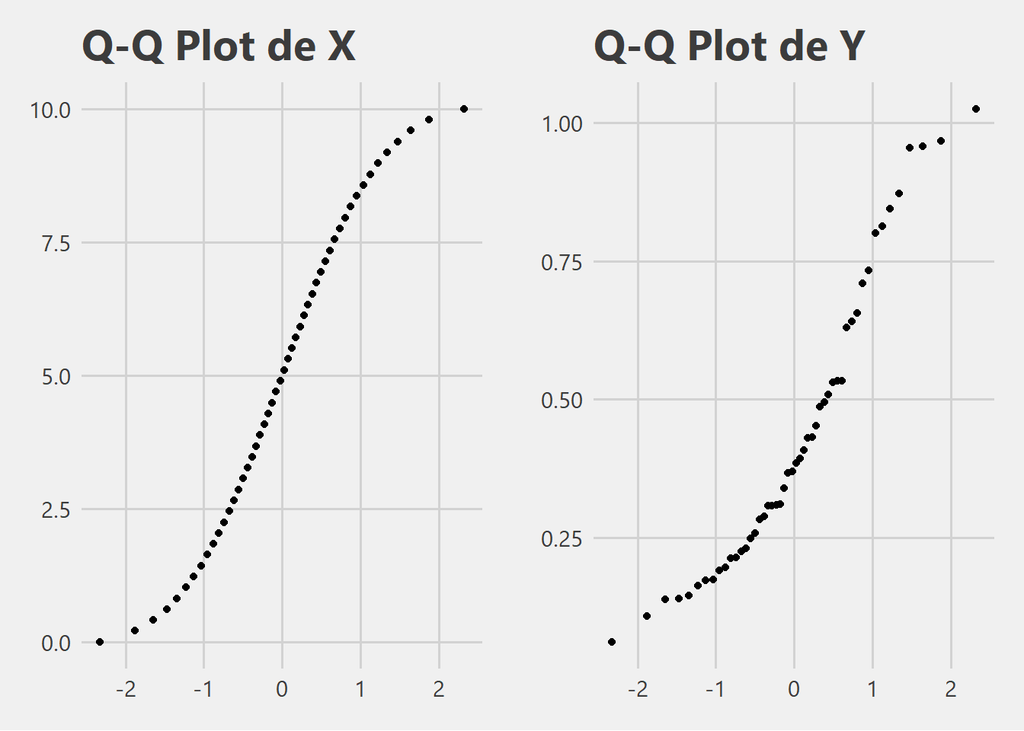

#### Interprétation du Q-Q Plot pour la variable `Y`

- **Écart par rapport à la diagonale** :  
  Pour la variable **$Y$**, les points du Q-Q plot ne suivent pas la droite diagonale. On observe une courbure, surtout aux extrémités, indiquant que les quantiles observés ne correspondent pas aux quantiles attendus pour une distribution normale.
- **Queues de distribution** :  
  Les écarts importants aux extrémités suggèrent que **$Y$** possède des caractéristiques non conformes à la normalité, telles qu’une asymétrie ou des queues de distribution différentes de celles d’une loi normale.

La variable **$Y$ ne semble pas suivre une distribution normale**.

### b) Etude numérique Shapiro-Wilk

Le **test de Shapiro-Wilk** est un test statistique permettant d’évaluer si un échantillon suit une **distribution normale**. Il est particulièrement efficace pour les **petites tailles d’échantillon** ($n \leq 50$), bien qu’il puisse être utilisé sur des ensembles de données plus grands.

#### Hypothèses du test

- **$H_0$ (Hypothèse nulle) :** Les données suivent une distribution normale.

#### Formule du test

La statistique du test de Shapiro-Wilk est définie comme suit :

$$W = \frac{( \sum_{i=1}^{n} a_i x_{(i)}
)^2}{\sum_{i=1}^{n} (x_i - \bar{x})^2}$$

**où** :

- $x_{(i)}$ sont les valeurs de l’échantillon classées par ordre croissant.
- $\bar{x}$ est la **moyenne** de l’échantillon.
- $a_i$ sont des coefficients calculés à partir des quantiles d’une distribution normale.

#### Interprétation des résultats

- Si la **p-valeur** du test est **supérieure à 0.05**, on **ne rejette pas** $H_0$ : l’échantillon peut être considéré comme **normalement distribué**.
- Si la **p-valeur** est **inférieure à 0.05**, on **rejette** $H_0$ : les données **ne suivent pas** une distribution normale.

#### Résultats du code R

```
##
##  Shapiro-Wilk normality test
##
## data:  data$X
## W = 0.95558, p-value = 0.05809
```

```
##
##  Shapiro-Wilk normality test
##
## data:  data$Y
## W = 0.92148, p-value = 0.002668
```

#### Variable `X`

Le test appliqué à **`X`** donne une statistique **W = 0.95558** avec une **p-valeur de 0.05809**.

Puisque la **p-valeur est supérieure à 0.05**, nous **ne rejetons pas** l’hypothèse de normalité.

Cela signifie que **la variable `X` suit une distribution normale** au seuil de 5%.

#### Variable `Y`

Le test appliqué à **`Y`** donne une statistique **W = 0.92148** avec une **p-valeur de 0.002668**.

Dans ce cas, la **p-valeur est inférieure à 0.05**, nous **rejetons donc** l’hypothèse de normalité.

Ainsi, nous pouvons conclure que **la variable `Y` ne suit pas une distribution normale**.

## **Question 6 :**

On sait que le coefficient de corrélation linéaire de Pearson se calcul de la façon suivante :

```
##
##  Pearson's product-moment correlation
##
## data:  data$X and data$Y
## t = -20.94, df = 48, p-value < 2.2e-16
## alternative hypothesis: true correlation is not equal to 0
## 95 percent confidence interval:
##  -0.9711081 -0.9120555
## sample estimates:
##        cor
## -0.9493844
```

Le coefficient de corrélation linéaire de Pearson est de **$-0,9493844$**. Ce coefficient est très proche de -1, ce qui indique une forte corrélation négative entre les deux variables. Cela signifie que $X$ et $Y$ évoluent de manière opposée (comme supposé avec la covariance). Cette relation est donc confirmée par le coefficient de corrélation élevé, qui suggère une forte dépendance linéaire entre les deux variables.

## **Question 7 :**

### Introduction

On sait qu’une droite affine s’exprime de la façon suivante : **$y = ax + b$**

Par la méthode de Legendre, aussi appelée méthode des moindres carrés, on peut trouver les coefficients $a$ et $b$ de la droite de régression linéaire qui minimise la somme des carrés des résidus. Autrement dit, on cherche $\hat{a}$ et $\hat{b}$ tels que :

$$f(\hat{a},\hat{b}) =
\arg\min_{(a,b)}\sum_{i=1}^N(y_i - (ax + b))^2$$

Cela signifie que nous cherchons les valeurs spécifiques de $a$ et $b$ qui rendent la somme des carrés des erreurs aussi petite que possible.

Dans un modèle linéaire, le meilleur coefficient directeur (au sens des moindres carrés) et la meilleure ordonnée à l’origine (au sens des moindres carrés) sont :

$$\hat{a} = \frac{\text{Cov}(x, y)}{\sigma_x^2}$$
et

$$\hat{b} = \bar{y} - \hat{a}x$$

### Démonstration

$$\frac{\partial f}{\partial a} = \sum_{i=1}^N (2*(y_i - ax_i -b)(-x_i))$$

$$\frac{\partial f}{\partial b} = \sum_{i=1}^N (2*(y_i - ax_i -b)(-1))$$

On cherche : $~~ \frac{\partial f}{\partial a} = 0~~$ et $~~ \frac{\partial f}{\partial b} = 0~~$

D’où le système suivant :

$$\begin{cases}
\sum 2(y_i - ax_i - b)(-x_i) = 0\\
\sum 2(y_i - ax_i - b)(-1) = 0
\end{cases}$$

En divisant par 2 :

$$\begin{cases}
\sum (y_i - ax_i - b)(-x_i) = 0\\
\sum (y_i - ax_i - b)(-1) = 0
\end{cases}$$

En divisant par $N$ :

$$\begin{cases}
\overline{(y - ax - b)x} = 0\\
\overline{y - ax - b} = 0
\end{cases}$$

Ce qui donne :

$$\begin{cases}
\overline{xy} - a\overline{x^2} - b\bar{x} = 0\\
\bar{y} - a\bar{x} - b = 0
\end{cases}$$

Multiplication de la seconde équation par $\bar{x}$ :

$$\begin{cases}
\overline{xy} - a\overline{x^2} - b\bar{x} = 0\\
\bar{x} \bar{y} - a\overline{x}^2 - b\bar{x} = 0
\end{cases}$$

Soustraction des deux équations :

$$(\overline{xy} - \bar{x} \bar{y}) - a(\overline{x^2} - \overline{x}^2) =
0$$

Ce qui donne :

$$\text{Cov}(X,Y) - a\sigma_X^2 = 0$$

D’où :

$$\hat{a} = \frac{\text{Cov}(X, Y)}{\sigma_X^2} ~~~ \text{et} ~~~ \hat{b}
= \bar{y} - \hat{a}\bar{x}$$

### Applications

Avec R, nous trouvons :

```
## a = -0.08351385 b = 0.8564897
```

Ainsi, nous obtenons :

$$\hat{a} = \frac{-0,7243548}{8,673469} = -0.08351385$$

**et**

$$\hat{b} = 0,4389205 - (−0.08351385*5) = 0.8564897$$

### Récapitulatif

Voici le nuage de points avec la droite de régression :

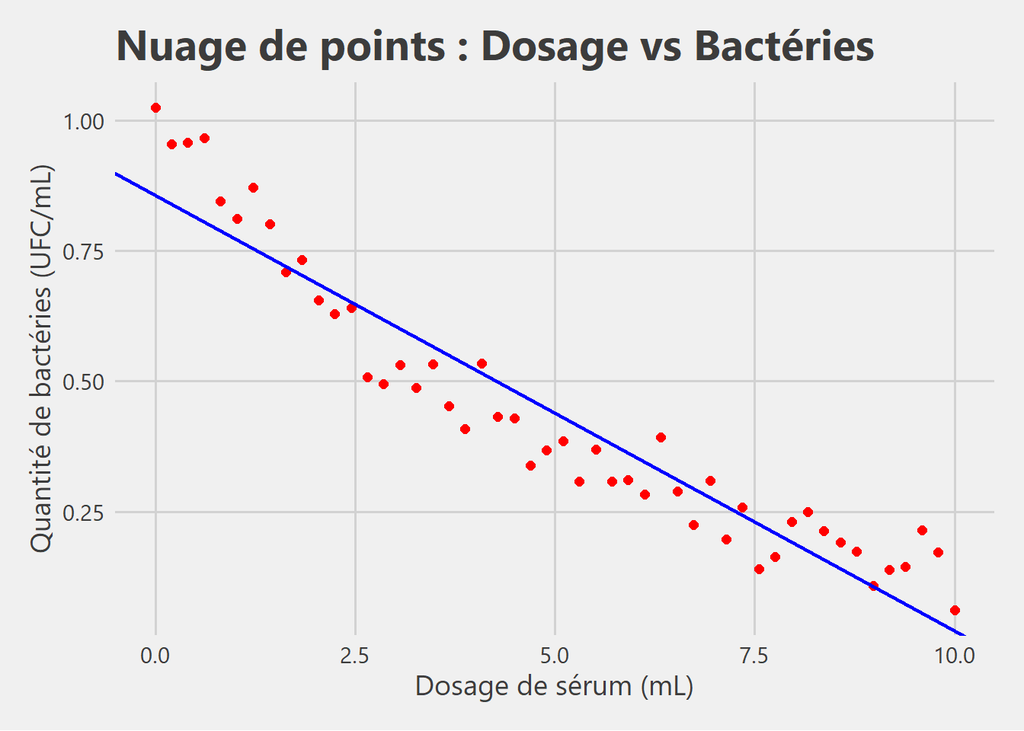

## **Question 8 :**

En observant le nuage de points, on voit clairement que lorsque le dosage de sérum augmente, la quantité de bactéries diminue de manière régulière. La droite de régression, qui semble plutôt passer au milieu de ces données, reflète bien cette tendance. Cette modélisation linéaire nous paraît être une première approximation logique et cohérente, en accord avec l’idée que l’augmentation du dosage se traduit par une diminution de la concentration bactérienne. L’ajustement linéaire offre ici une représentation intuitive et assez satisfaisante de la relation observée.

## **Question 9 :**

Résultat du code R pour `summary()` :

```
##
## Call:
## lm(formula = data$Y ~ data$X)
##
## Residuals:
##      Min       1Q   Median       3Q      Max
## -0.12653 -0.06608 -0.01112  0.05365  0.16835
##
## Coefficients:
##              Estimate Std. Error t value Pr(>|t|)
## (Intercept)  0.856490   0.023144   37.01   <2e-16 ***
## data$X      -0.083514   0.003988  -20.94   <2e-16 ***
## ---
## Signif. codes:  0 '***' 0.001 '**' 0.01 '*' 0.05 '.' 0.1 ' ' 1
##
## Residual standard error: 0.08306 on 48 degrees of freedom
## Multiple R-squared:  0.9013, Adjusted R-squared:  0.8993
## F-statistic: 438.5 on 1 and 48 DF,  p-value: < 2.2e-16
```

### Test de significativité globale du modèle

Avant d’interpréter les résultats, il convient d’évaluer la significativité du modèle. Il désigne le seuil à partir duquel les résultats d’un test sont jugés fiables. Autrement dit, ce seuil détermine la confiance dans la corrélation entre un test effectué et les résultats obtenus.

Soit : $H_0$ -> le modèle n’est pas significatif

Ce test est basé sur la **statistique de Fisher** présentée en bas de la sortie R. La p-valeur associée à cette statistique est de **`2e-16`**. Puisque cette valeur est **inférieure à 1%**, nous **rejetons l’hypothèse nulle**, à savoir le modèle est bien **globalement significatif**

### Interprétation des coefficients

Les coefficients permettent de comprendre comment la variable explicative $X$ influence la variable dépendante $Y$.

**`(Intercept)`** qui est dans notre cas $~\hat{b}~$ (que nous allons appelé $~\beta_0$), est de **0.85649**. Et **`data$X`** qui est $~\hat{a}~$ (que nous allons appelé $~\beta_1$), est de **-0.08351**. Ces valeurs correspondent à celles que nous avons calculées précédemment.

Les **`Pr(>|t|)`** sont les **`p-valeurs`** associées à chaque coefficient. Elles permettent de tester **l’hypothèse nulle** $H_0$ suivante :

- $H_0 : \beta_i = 0 ~$ -> Cela signifie que $X$ n’a aucun effet sur $Y$

Or, ici les **p-valeurs sont très faibles** (**`2e-16`**), ce qui signifie que nous **rejetons l’hypothèse nulle**. Donc **les coefficients sont significatifs** et que la variable explicative $X$ a un effet significatif sur la variable dépendante $Y$.

De plus, dans R la signification des coefficients est indiquée avec des étoiles. Ici nous avons **3 étoiles** (**`***`**), ce qui signifie que les coefficients sont très significatifs.

### Residuals

Nous avons un **minimum à -0.12653** et un **maximum à 0.16835**. Ces valeurs montrent que les résidus restent dans un **intervalle restreint**. Cela signifie que le modèle fait des **erreurs relativement petites** et que ses **prédictions sont assez précises**.

De plus, **la médiane des résidus est proche de 0**, ce qui indique que le modèle est **équilibré** et que les erreurs sont réparties de manière homogène autour de la droite de régression.

### Multiple R-squared

Le coefficient de détermination $R^2$ est de **0.9013**. Cela signifie que **90.13% de la variance de la variable dépendante $Y$ est expliquée par la variable explicative $X$**. Ce coefficient est très élevé, ce qui indique que le modèle linéaire est **très performant** pour prédire la quantité de bactéries en fonction du dosage de sérum.

## **Question 10 :**

A l’aide de R, on trouve :

```
## SCR = 0.3311143
```

$$SCR = 0.3311143$$

### Interprétation

Plus la $SCR$ est faible, plus le modèle est performant. Dans notre cas, la $SCR$ est de **0.3311143**, ce qui indique que le modèle linéaire explique une grande partie de la variance de la variable dépendante $Y$. Cela confirme la pertinence du modèle pour prédire la quantité de bactéries en fonction du dosage de sérum.

## **Question 11 :**

### a) Évaluer l’indépendance des résidus

#### i)

##### **Qu’est ce que la fonction `acf()`**

En général, la fonction **`acf()`** permet de tracer la fonction d’autocorrélation d’une série temporelle. Elle permet de visualiser les corrélations entre les observations d’une série en fonction du décalage entre elles.

Voici le graphique obtenu à l’aide de R :

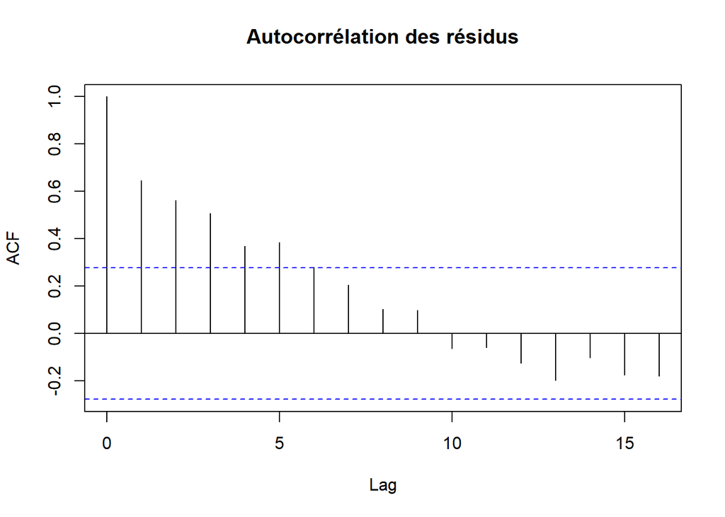

##### **Interprétation du graphique**

On voit qu’au début, les résidus sont fortement corrélés, puis la corrélation diminue progressivement pour devenir proche de zéro. Cela indique que les résidus ne sont pas indépendants les uns des autres et qu’il y a une certaine autocorrélation positive.

Ce résultat es assez logique. En effet, lors de la première administration du sérum, la quantité de bactéries diminue. Lors de la deuxième administration, la quantité de bactéries diminue à nouveau, mais elle est déjà plus faible qu’après la première administration. Ainsi, les résidus sont corrélés, car la quantité de bactéries dépend de la quantité précédente.

On notera aussi le fait, que nous ne connaissons rien de cette bactérie, il est donc normal que la partie résiduelle soit élevé au début et diminue au fur et à mesure des administrations. Car l’individu se débarrasse de la bactérie et donc se rapproche d’un état de santé que nous pouvons expliqué.

#### ii)

Le test de Durbin-Watson (DW) est un test statistique utilisé en régression linéaire pour détecter l’autocorrélation des erreurs (résidus) dans un modèle. Autrement dit, il permet de vérifier si les résidus sont indépendants les uns des autres.

A l’aide de R, on obtient :

```
##
##  Durbin-Watson test
##
## data:  LMS
## DW = 0.61628, p-value = 1.655e-09
## alternative hypothesis: true autocorrelation is greater than 0
```

Avant de commencer, dans ce test, il est fait l’hypothèse suivante :

- $H_0$ : Les erreurs (résidus) ne sont pas autocorrélées. Autrement dit, elles sont indépendantes les unes des autres

##### **Comment interpréter les résultats ?**

Statistique de Durbin-Watson (DW) :

- Si **`DW`** est proche de **2**, cela signifie qu’il n’y a pas d’autocorrélation.
- Si **`DW`** proche de **0**, cela indique une forte autocorrélation positive des résidus.
- Si **`DW`** proche de **4**, cela indique une forte autocorrélation négative des résidus.

Nous trouvons un **`DW` de 0.61628**. Cette valeur est **inférieure à 2**, ce qui suggère une **forte autocorrélation positive des résidus**.

De plus, la **`p-value`** associée à ce test est de **1.655e-09**, ce qui est **inférieur à 0.05**. Nous **rejetons donc l’hypothèse nulle** $H_0$ et concluons que les résidus ne sont pas indépendants les uns des autres.

Cette fois-ci, nous avons en plus **`alternative hypothesis`** qui est une hypothèse alternative. Celle-ci est **`positive`**, ce qui signifie que les résidus sont **positivement autocorrélés**.

##### **Conclusion général :**

Les résidus du modèle de régression linéaire ne sont pas indépendants les uns des autres. Il existe une forte autocorrélation positive entre les résidus.

### b) Tester la normalité des résidus

#### i)

Pour rappel, nous faisons l’hypothèse suivante :

- **$H_0$ (Hypothèse nulle) :** Les données suivent une distribution normale.

A l’aide de R, on obtient :

```
##
##  Shapiro-Wilk normality test
##
## data:  residuals(LMS)
## W = 0.95739, p-value = 0.06909
```

Le test appliqué aux résidus donne une statistique **`W` = 0.95739** avec une **p-valeur de 0.06909.**

Puisque **la p-valeur est supérieure à 0.05**, nous **ne rejetons pas l’hypothèse** de normalité.

Cela signifie que **les résidus `(SCR)` suivent une distribution normale** au seuil de 5%.

#### ii)

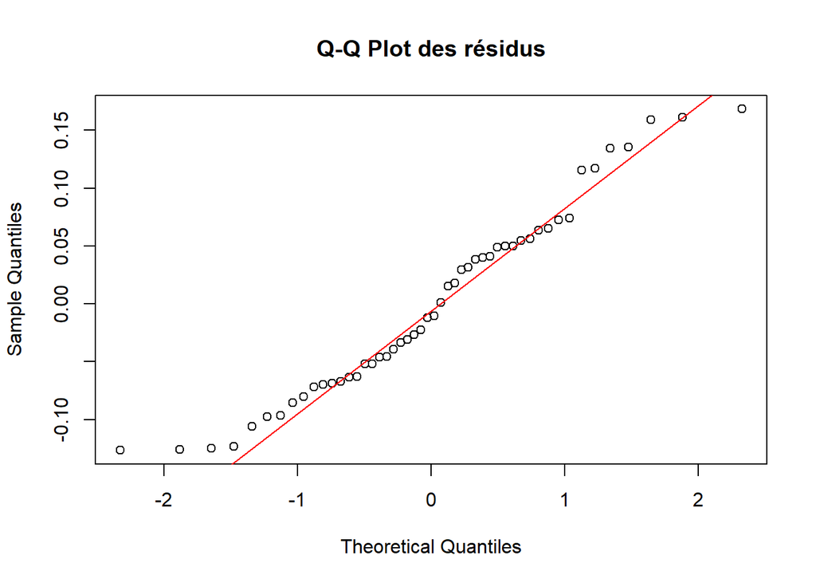

##### **Interprétation du Q-Q Plot**

Les **résidus semblent donc être normalement distribué.**

##### **Conclusion générale**

Le test de **Shapiro-Wilk** et le **Q-Q plot** des résidus indiquent que ces derniers suivent une **distribution normale**. Cela confirme que les résidus du modèle de régression linéaire sont bien distribués selon une **loi normale**.

## **Question 12 :**

### **Un peu de mathématiques !**

Nous cherchons à ajuster un modèle exponentiel de la forme :

$$y = b \cdot a^x$$

où $a$ et $b$ sont les paramètres à estimer à partir des données $(x, y)$.

### **Transformation logarithmique**

L’équation exponentielle n’étant pas linéaire, nous appliquons le logarithme népérien des deux côtés :

$$\ln y = \ln b + x \ln a$$

En posant :

$$z = \ln y, \quad \alpha = \ln a, \quad \beta = \ln b,$$

nous obtenons une équation linéaire :

$$z = \alpha x + \beta$$

**Attention :** Ici, $z$ représente les valeurs transformées $\ln y$, et **non** les valeurs originales de $y$.

Nous pouvons maintenant estimer les paramètres $\alpha$ et $\beta$ à l’aide d’une régression linéaire entre $x$ et $y$.

### **Estimation des paramètres**

La pente de la droite de régression est donnée par :

$$\alpha= \frac{\text{Cov}(x, z)}{\sigma^2_x}$$

où $\text{Cov}(x, z)$ est la covariance entre $x$ et $z$, et $\sigma^2_x$ est la variance de $x$.

**Attention :** Ce coefficient $\alpha$ correspond à $\ln a$, **et non** directement à $a$.

L’ordonnée à l’origine est :

$$\beta = \overline{z} - \alpha \cdot \overline{x}$$

où $\overline{z}$ et $\overline{x}$ sont respectivement les moyennes de $z$ et $x$.

### **Récupération des coefficients $a$ et $b$**

Étant donné que $\alpha = \ln a$ et $\beta = \ln b$, nous retrouvons les valeurs de $a$ et $b$ par exponentiation :

$$a = e^\alpha, \quad b = e^\beta.$$

### **Modèle final**

En réinjectant ces valeurs dans l’équation exponentielle initiale, nous obtenons la fonction qui traduit la courbe ajustée :

$$\hat{y}_{exp} = e^\beta \cdot (e^\alpha)^x$$

Par définition des exponentielles, cela revient à :

$$\hat{y}_{exp} = e^\beta \cdot e^{\alpha x}$$

### **Conclusion**

Grâce à cette méthode, nous avons pu estimer les paramètres $\alpha$ et $\beta$ du modèle exponentiel en appliquant une régression linéaire sur les valeurs transformées $z ~(\ln y)$. L’exponentiation des coefficients obtenus nous permet de retrouver les valeurs finales de $a$ et $b$, garantissant un ajustement correct du modèle exponentiel aux données.

```
## Alpha = -0.2093764 Beta = 1.034294
```

### **Modèle exponentiel ajusté**

$$\hat{y}_{exp} = 1.034294 \times e^{-0.2093764 x}$$

Visualisation du nuage de points avec les droites de régression linéaire et exponentielle :

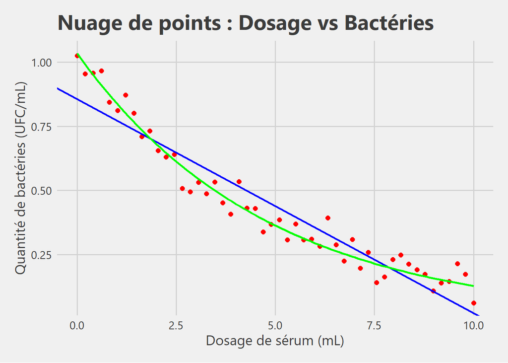

## **Question 13 :**

L’objectif est de comparer les modèles **linéaire** et **exponentiel** en utilisant le coefficient de détermination $R^2$.

Le coefficient de détermination $R^2$ est défini comme :

$$R^2 = \frac{SCE}{SCT}$$

où :

- $SCE$ est la Somme des Carrés Expliquée par le modèle.
- $SCT$ est la Somme des Carrés Totale, représentant la variabilité totale des données.

### **Calcul de $R^2$ pour les modèles linéaire et exponentiel**

#### **Modèle linéaire**

En utilisant R :

```
## [1] 0.9013307
```

Le résultat obtenu est :

$$R^2_{lin} = 0.9013$$

#### **Modèle exponentiel**

A l’aide du logarithme népérien, nous avons estimé les paramètres $\alpha$ et $\beta$ du modèle exponentiel. En utilisant R, on trouve le R² suivant :

```
## [1] 0.9151224
```

Le résultat obtenu est donc :

$$R^2_{exp} = 0.9151$$

#### **Interprétation des résultats :**

Les valeurs obtenues sont :

- **Modèle linéaire** : $R^2 = 0.9013$
- **Modèle exponentiel** : $R^2 = 0.9151$

On observe que le modèle exponentiel présente un **coefficient $R^2$ légèrement plus élevé** que le modèle linéaire. Cela signifie que l’ajustement exponentiel explique **un peu mieux** la variabilité des données.

### Interprétation des résultats avec `summary()`

Outre $R^2$, les résultats de `summary()` nous donnent plusieurs indications sur les modèles :

### 2. **Analyse du modèle linéaire**

#### **Interprétation :**

- Le modèle linéaire est également **très significatif**.
- Son erreur standard résiduelle est **plus faible** que le modèle exponentiel, ce qui peut indiquer une meilleure précision locale.

### Comparaison des modèles

[output not shown]

### **Analyse finale :**

Le **modèle exponentiel** a un $R^2$ **légèrement plus élevé**, suggérant qu’il explique mieux la variance des données.

Le **modèle linéaire a une erreur résiduelle plus faible**, ce qui peut indiquer une meilleure précision locale.

**Les deux modèles sont hautement significatifs (p-value < 2.2e-16)**, donc l’un comme l’autre sont pertinents.

## **Question 14 :**

Nous cherchons à calculer, à partir de chacun des deux modèles, une prévision de la quantité de bactérie encore présente dans le corps 24 heures après l’injection d’une dose de 8 mL de sérum.

### **Modèle exponentiel**

Dans le modèle exponentiel, nous avons :

$$\hat{y}_{exp} = 1.034294 \times e^{-0.2093764 x}$$

En remplaçant $x = 8$ :

```
## Y exponentiel = 0.1937295
```

### **Modèle linéaire**

Dans le modèle linéaire, nous avons :

$$\hat{y}_{lin} = -0,083513x + 0,856489$$

En remplaçant $x = 8$ :

```
## Y linéaire = 0.188379
```

### **Résultats**

- **Modèle exponentiel** : $0.193729$
- **Modèle linéaire** : $0.188379$

## Analyse des résultats

Nous avons trouvé à la **question 13** que le modèle exponentiel explique un peu mieux la variance des données, mais que le modèle linéaire a une erreur résiduelle plus faible.

Donc, pour une dose de 8 mL de sérum, nous pouvons conclure que les deux modèles donnent des résultats relativement proches. Cela signifie que les deux modèles peuvent être utilisés pour prédire la quantité de bactéries restante après 24 heures. Cependant, le modèle linéaire semble plus précis pour des valeurs proches de 8, tandis que le modèle exponentiel est plus précis pour des valeurs plus éloignées.

### **Interprétation**

Ne sachant pas vraiment qu’elle choix faire entre les deux modèles, nous allons prendre la moyenne des deux résultats pour obtenir une prévision plus fiable.

Calculons la moyenne des deux résultats :

```
## Moyenne des deux modèles = 0.1910542
```

### **Conclusion**

En moyenne, les deux modèles prévoient une densité de bactéries d’environ **0.1910542 UFC/mL** après 24 heures. Cette valeur peut être utilisée pour évaluer l’efficacité du sérum et la diminution de la densité de zombies dans le corps.

## **Bonus**

Nous pensons que Rick fera décroitre la densité de zombie quand la quantité de bactéries Y (en UFC/mL) sera nulle. On cherche donc à déterminer le temps nécessaire pour que la quantité de bactéries soit nulle. Pour cela, nous allons résoudre l’équation $y = 0$ pour chacun des modèles.

### **Modèle exponentiel**

Résolvons l’équation $y = 0$ pour le modèle exponentiel :

$$y = 0 \Longleftrightarrow 1.034294 \times e^{-0.2093764 x} = 0$$

Cependant, il n’existe **aucune solution réelle** à cette équation. En effet, la fonction exponentielle $e^{-kx}$ est strictement positive pour tout réel $x$, quelle que soit la valeur de $k > 0$. Ainsi, le produit d’une constante strictement positive par une exponentielle décroissante reste toujours strictement positif.

Autrement dit :

$$\forall x \in \mathbb{R}, \quad y(x) > 0$$

#### Étude de la limite lorsque $x \to +\infty$

Même si la fonction n’atteint jamais la valeur zéro, on peut s’intéresser à son comportement à l’infini. Calculons la limite :

$$\lim_{x \to +\infty} y(x) = \lim_{x \to +\infty} 1{,}034294 \cdot
e^{-0{,}2093764x}$$

On sait que :

$$\lim_{x \to +\infty} e^{-kx} = 0 \quad \text{pour tout } k > 0$$

donc :

$$\lim_{x \to +\infty} y(x) = 0$$

#### Conclusion

La fonction $y(x) = 1{,}034294 \cdot e^{-0{,}2093764x}$ tend vers zéro quand $x \to +\infty$, mais ne l’atteint jamais. Il s’agit donc d’une asymptote horizontale en $y = 0$, ce qui explique l’absence de solution réelle à l’équation $y(x) = 0$.

### **Modèle linéaire**

Appliquons le même raisonnement pour le modèle linéaire :

$$\hat{y} = 0 \Longleftrightarrow -0,083513x + 0,856489 = 0$$

$$\Longleftrightarrow -0,083513x = -0,856489$$

$$\Longleftrightarrow x = \frac{-0,856489}{-0,083513}$$

$$\Longleftrightarrow x \simeq 10.25566$$

```
## X linéaire = 10.25566
```